# SECOND HOMEWORK: SUPERVISED LEARNING

Statistical Learning. Bachelor in Data Science and Engineering

Alejandro Leonardo García Navarro

December 18, 2022

# 1 Introduction to the homework.

The aim of this homework is to apply supervised-learning tools to an open data set. Modern organizations and services already heavily rely on machine learning to function. Machine learning models are used in a range of contexts, including social networking platforms, healthcare, and finance. However, depending on the task and the data that is available, different procedures will be required to train and implement a model.

There are two different approaches to machine learning model development, supervised and unsupervised learning, as examples. They differ in terms of how the models are trained and the quality of the necessary training data. A supervised learning model will typically encounter a different task or difficulty than an unsupervised learning model because each approach has different capabilities.

Its name, “supervised machine learning,” refers to the fact that at least some of this method requires human supervision. Most of the information that is available is unlabeled, raw information. For data to be adequately labeled and ready for supervised learning, human input is typically necessary.

Basically, supervised machine learning is used to classify unseen data into established categories and forecast trends and future change as a predictive model. A model developed through supervised machine learning will learn to recognize objects and the features that classify them.

To proceed with the project, it was asked to select two important variables as targets: one categorical (for classification) and the other one numerical (for regression).

In order to do so, it was proposed to think about some goals or questions that may be desired to answer and, finally, get convenient insights and conclusions from the output of the tools.

# 2 Information regarding the chosen dataset.

Before starting with the homework, it is of high vitality to both show and explain the basics of the chosen data set. This data set contains an airline passenger satisfaction survey and the main goal of it is to have a comprehensive understanding of what factors lead to customer satisfaction for an airline; that is, what factors are highly correlated to a satisfied or dissatisfied passenger?

It contains several variables. To be precise, 25:

- X: Refers to the number of row.
- ID: Identifier of each passenger.
- Gender: Gender of the passengers (Female, Male).
- Customer Type: The customer type (Loyal customer, disloyal customer).
- Age: The actual age of the passengers.
- Type of Travel: Purpose of the flight of the passengers (Personal Travel, Business Travel).
- Class: Travel class in the plane of the passengers (Business, Eco, Eco Plus).
- Flight distance: The flight distance of this journey.
- Inflight wifi service: Satisfaction level of the inflight wifi service (0:Not Applicable;1-5).
- Departure/Arrival time convenient: Satisfaction level of Departure/Arrival time convenient.
- Ease of Online booking: Satisfaction level of online booking.
- Gate location: Satisfaction level of Gate location.
- Food and drink: Satisfaction level of Food and drink.
- Online boarding: Satisfaction level of online boarding.
- Seat comfort: Satisfaction level of Seat comfort.
- Inflight entertainment: Satisfaction level of inflight entertainment.
- On-board service: Satisfaction level of On-board service.
- Leg room service: Satisfaction level of Leg room service.
- Baggage handling: Satisfaction level of baggage handling.
- Check-in service: Satisfaction level of Check-in service.
- Inflight service: Satisfaction level of inflight service.
- Cleanliness: Satisfaction level of Cleanliness.
- Departure Delay in Minutes: Minutes delayed when departure.
- Arrival Delay in Minutes: Minutes delayed when Arrival.
- Satisfaction: Airline satisfaction level (Satisfaction, neutral or dissatisfaction).

## 2.1 Loading dataset.

The data set is uploaded using the ‘read.csv’ function. It is known that the most common way that scientists store data is in Excel spreadsheets. While there are R packages designed to access data from Excel spreadsheets, it is often easier to save spreadsheets in comma-separated values files (CSV) and then use R’s built in functionality to read and manipulate the data.

```r
set.seed(123)
# STEP 1: Erase the global environment.
rm(list = ls())

# STEP 2: Install useful packages.
# Library that contains new tools for the visualization of missing values.
library(VIM)

# Library used for data visualization.
library(ggplot2)
library(cowplot)

# Library focused on tools for working with data frames.
library(dplyr)

# Library that is a collection of R packages designed for data science.
library(tidyverse)

# Library that extends 'ggplot2'. Mainly used to make heatmap-like graphs.
library(GGally)

# Libraries used for clustering. In particular, the library 'mclust' is an
# R package for model-based clustering, classification, and density estimation
# based on finite normal mixture modelling.
library(cluster)
library(mclust)

# Libraries used for classification.
library(skimr)
library(mice)
library(MASS)
library(glmnet)
library(e1071)
library(rpart)
library(pROC)
library(class)
library(randomForest)
library(caret)
library(rpart.plot)

# Libraries for regression.
library(olsrr)
library(elasticnet)


# STEP 3: Load dataset.
passengers <- read.csv("passengers.csv")
dataset <- as.data.frame(passengers)
```

# 3 Data preprocessing.

Once the data is uploaded, the very first thing that must be carried out is the so-called ‘Data cleaning’. This is the process of fixing or removing incorrect corrupted, incorrectly formatted, duplicated, or incomplete data within a data set. There are several steps that must be followed.

## 3.1 STEP 1: Removing duplicated or irrelevant observations.

By observing the data set, it appears that, as of right now, two variables seem to be useless; ‘X’ and ‘id’. First off, ‘X’ indicates the number of row. Consequently, is is deleted, since rows are already numbered. Moving on, as in this project it is not desired to analyze the passengers by themselves, but rather their answers to the surveys, the variable ‘id’ can be omitted.

```r
dataset$X <- NULL
dataset$id <- NULL
```

Once irrelevant observations are deleted, it is now time to remove the duplicates, in case there are any. To do so, the function ‘duplicated()’ is used. It determines which elements of a vector or data frame are duplicates of elements with smaller subscripts, and returns a logical vector indicating which elements (rows) are duplicates.

Moreover, due to the extent of this dataset, it will be impossible to recognize which rows contain ‘TRUE’ values just by observing it (the line duplicated(dataset) would be run in case this method was to be applied). Due to this exact purpose, other method is followed.

Another dataset is created using ‘!duplicated()’, where ‘!’ indicates logical negation, so that a data set with no duplicates is obtained. Then, the original and the new data set are compared to know if there where duplicates or not.

```r
data_unique <- dataset[!duplicated(dataset),]
identical(dataset, data_unique)
```

```
## [1] TRUE
```

Hence, as they are identical, there are no duplicates in the dataset.

## 3.2 STEP 2: Fix or remove typos or errors.

Having analyzed all the columns, no big typos or errors are spotted. Nonetheless, in order to provide a more straightforward output, the ‘satisfaction’ column is modified to have ‘satisfied’ and ‘dissatisfied’; instead of ‘satisfied’ and ‘neutral or dissatisfied’.

```r
data_unique$satisfaction[data_unique$satisfaction == "neutral or dissatisfied"] <- "dissatisfied"
```

Furthermore, it is a must to take into account that the categorical variables must be transformed into factors. Factors are data structures in R that store categorical data. In datasets, there are often fields that take only a few predefined values. Hence, some modifications must be performed.

```r
data_unique$Gender = as.factor(data_unique$Gender)
data_unique$Customer.Type = as.factor(data_unique$Customer.Type)
data_unique$Type.of.Travel = as.factor(data_unique$Type.of.Travel)
data_unique$Class = as.factor(data_unique$Class)
data_unique$satisfaction = as.factor(data_unique$satisfaction)
```

Besides, before finishing this phase, it is decided to transform variables that are numbers into numeric. This is done not because it is vital, but because it may provide better ease during certain phases of the project.

```r
data_unique[c(3, 6:22)] <- lapply(data_unique[c(3, 6:22)], as.numeric)
```

## 3.3 STEP 3: Missing values.

A missing value is a non-present value in a variable. It is a must to identify them and decide what to do.

```r
sum(is.na(data_unique))
```

```
## [1] 310
```

With the help of the function ‘aggr()’, it is possible to visually see which specific variables contain empty values.

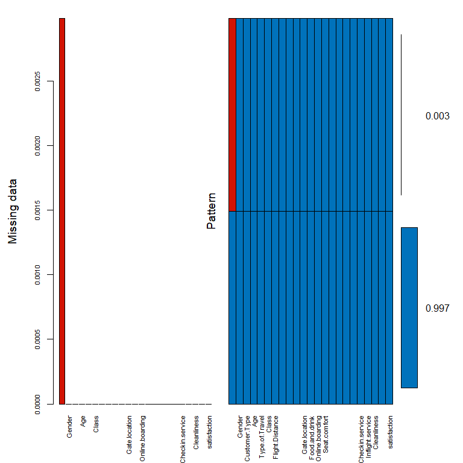

```
##
##  Variables sorted by number of missings:
##                           Variable       Count
##           Arrival.Delay.in.Minutes 0.002983523
##                             Gender 0.000000000
##                      Customer.Type 0.000000000
##                                Age 0.000000000
##                     Type.of.Travel 0.000000000
##                              Class 0.000000000
##                    Flight.Distance 0.000000000
##              Inflight.wifi.service 0.000000000
##  Departure.Arrival.time.convenient 0.000000000
##             Ease.of.Online.booking 0.000000000
##                      Gate.location 0.000000000
##                     Food.and.drink 0.000000000
##                    Online.boarding 0.000000000
##                       Seat.comfort 0.000000000
##             Inflight.entertainment 0.000000000
##                   On.board.service 0.000000000
##                   Leg.room.service 0.000000000
##                   Baggage.handling 0.000000000
##                    Checkin.service 0.000000000
##                   Inflight.service 0.000000000
##                        Cleanliness 0.000000000
##         Departure.Delay.in.Minutes 0.000000000
##                       satisfaction 0.000000000
```

```r
aggr(data_unique, col = c("#0072BB", "#D21404"), numbers = TRUE, sortVars = TRUE, labels = names(dataset), cex.axis = .7, gap = 1, ylab= c('Missing data','Pattern'))
```

As demonstrated, the missing values are on the ‘Arrival.Delay.in.Minutes’ variable. As of right now, several steps must be followed:

```
1. Determine what to do:
As stated in class, if they are just a few and not relevant, they can be deleted.
Say less than 5% of the sample. Otherwise:
    a) We can remove rows when most of their corresponding variables are empty.
    b) We can remove columns when most of their corresponding rows are empty.

2. Delete missing values:
In this case, 5195,2 is 5% of 103904. Since there are 310, that is, less than
5% of the sample, the decision of removing these is taken.
```

```r
final_dataset <- na.omit(data_unique)
```

Nonetheless, one may wonder what should be done in case there were more than 5% of the sample. The answer is that these must be replaced with the mean. The process would be the following:

```r
#final_dataset <- data_unique
#for (i in 1:ncol(final_dataset)){
#  final_dataset[,i][is.na(final_dataset[,i])] <- mean(final_dataset[,i], na.rm = TRUE)
#}
```

As can be seen above, a ‘for loop’ would be used to optimize the process of deleting “NA” values. If this was not performed like this way, it should be done one by one, knowing beforehand which variables had missing values, which could have taken more than usual.

## 3.4 STEP 4: Outliers.

Before dealing with outliers, it is key to understand what these are. An outlier is an observation that lies an abnormal distance from other values in a random sample from a population (for example, if it is desired to study the weight of people an all the provided values ranges between 40kg-60kg, then, an outlier would be 700kg). There are several ways of checking these: either make a boxplot for every single variable or make a general boxplot for the entire dataset. The second method is followed.

In order to see clearly the boxplots, the function ‘par()’ was used. The par() function is used to set or query graphical parameters. We can divide the frame into the desired grid, add a margin to the plot or change the background color of the frame by using the par() function. We can even utilize it to create multiple plots at once.

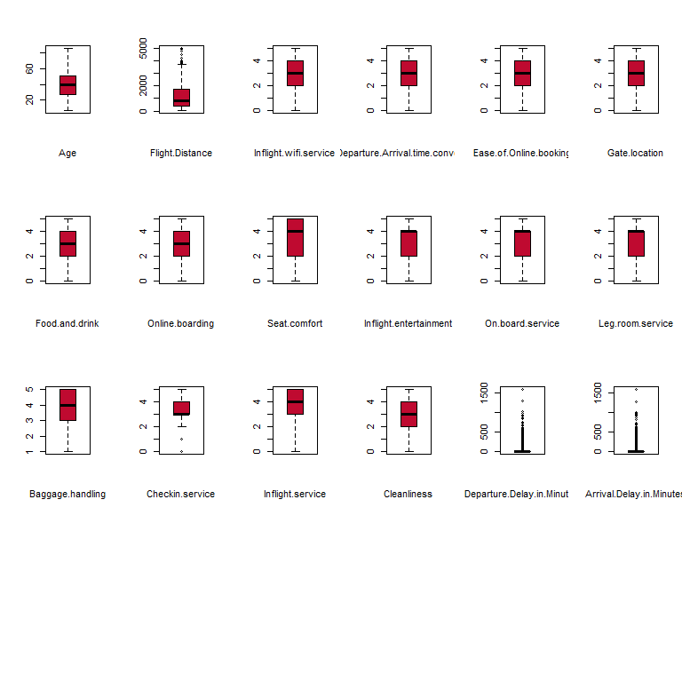

```r
# So, firstly, the number of rows(4) and columns(5) are specified, respectively.
par(mfrow=c(4, 6))

# Then, a 'for loop' is used to retrieve all the boxplots.
cols <- c(3, 6:22)
for (i in(cols)){
  boxplot(final_dataset[i], col = "#BF0A30",xlab = names(final_dataset)[i])
}
```

One can spot that variables like ‘Flight.Distance’, ‘Checkin.service’, ‘Departure.Delay.in.Minutes’ and ‘Arrival.Delay.in.Minutes’ contain outliers. Howbeit, a closer look in these variables is required to get better understandings and, therefore, take decisions.

After having analyzed them closer, now it is in our hands to whether or not get rid of these values. After a considering time debating this, the decision of not deleting any of the outliers was taken. This is because these values may influence the rest, specially ‘satisfaction’, which constitutes a key pillar in the dataset.

Still, if these values were to be deleted, an easy process would be followed. To do this, a fast method is applied. Instead of going through every column of the dataset and plot the boxplot, it is better to implement a ‘for loop’ that goes through the entire dataset and marks the outliers as empty values.

```r
#for (i in c(2:12)){
#  value = data_unique[,i][data_unique[,i] %in% boxplot.stats(data_unique[,i])$out]
# data_unique[,i][data_unique[,i] %in% value] = NA}

# Therefore, these would be deleted:
# final_dataset <- na.omit(data_unique)
```

## 3.5 STEP 5: Conclusion of data preprocessing.

As of right now, the first part of the project is finished. In this part, as a recapitulation, the following changes were performed: 1. Removed two irrelevant columns. 2. Removed duplicates. 3. Fixed the variable ‘satisfaction’. 4. Transformed variables into factors and numeric to ease some processes. 5. Detected outliers.

It can even be observed how much of our dataset was retained, and how much was deleted.

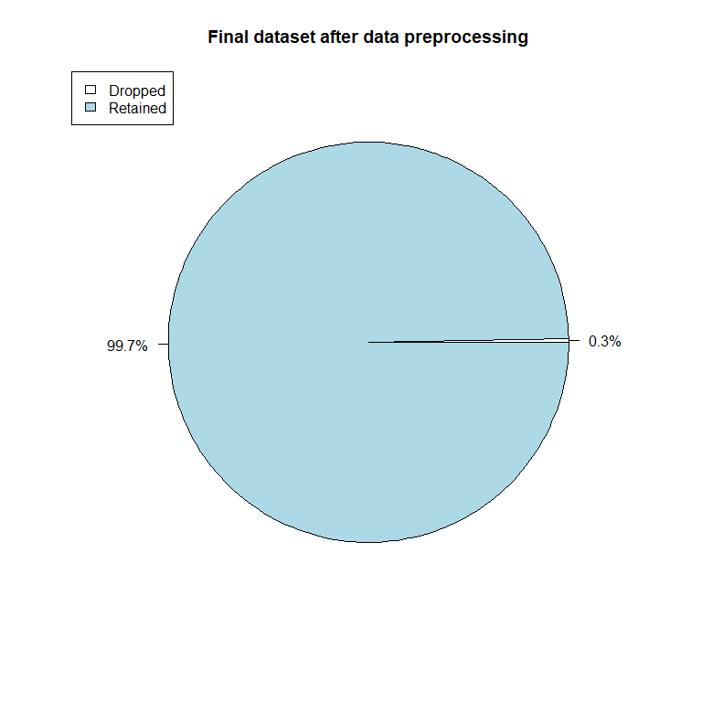

```r
values_now <- as.numeric(nrow(final_dataset))
values_before <- as.numeric(nrow(dataset)) - values_now
count <- c(values_before, values_now)
pie_labels <- paste0(round(100 * count/sum(count), 2), "%")
pie(count, labels = pie_labels, main="Final dataset after data preprocessing")
legend("topleft", legend = c("Dropped", "Retained"),
       fill =  c("white", "lightblue"))
```

# 4 Visualization tools to get insights before the tools.

For this part, it is basically asked to perform an exploratory data analysis. This refers to the critical process of performing initial investigations on data so as to discover patterns, to spot anomalies, to test hypothesis and to check assumptions with the help of summary statistics and graphical representations.

A step of high vitality to perform is to obtain a heatmap that shows us how related are the variables among them. With this, certain queries can be proposed and, hence, be able to fully understand the relation among the variables contained in the dataset.

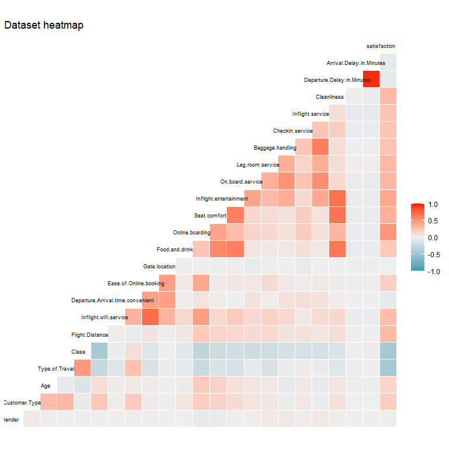

```r
data_heatmap <- as.data.frame(sapply(final_dataset, as.numeric))
ggcorr(data_heatmap, hjust = 0.75, size = 2.5) + ggplot2::labs(title = "Dataset heatmap")
```

This heatmap shows the correlation coefficients among all the variables. The correlation coefficient is a statistical measure of the strength of a linear relationship between two variables. Its values can range from -1 to 1: - A correlation coefficient of -1 describes a perfect negative correlation. - A coefficient of 1 shows a perfect positive correlation. - A correlation coefficient of 0 means there is no linear relationship.

Furthermore, as illustrated, variables along the lines of ‘Inflight.wifi.service’, ‘Food.and.Drink’ or even ‘Seat.comfort’ are worth studying.

For this part of the project, several questions are proposed to get valuable information from the variables, as well as check if certain values of one variable directly affects the values of other.

```
Q1: Is the travel class in somehow related to the satisfaction of the passengers?
If so, which class is the most satisfied?
```

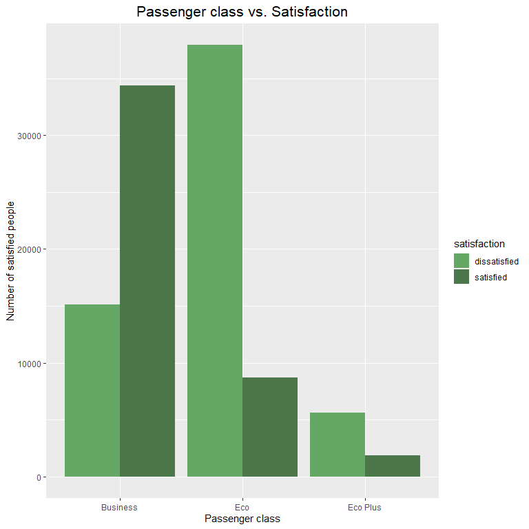

```r
ggplot(final_dataset) + aes(x = Class, fill = satisfaction) +
  geom_bar(position = 'dodge') +
  xlab('Passenger class') + ylab('Number of satisfied people') +
  scale_fill_manual(values = c("#65a765", "#4B774B")) +
  labs(title = "Passenger class vs. Satisfaction") +
  theme(plot.title = element_text(size = 16L, hjust = 0.5))
```

According to the graph shown above, it is clear that those passengers belonging to Business class are the most satisfied ones. By seeing these results, it is clear that some improvements must be done in the rest of the classes. Moreover, further investigations could be pursued and discover what is that causes this big dissatisfaction among the passengers of other classes.

```
Q2: We all are passengers, may it be of cars, trains, planes... and we know
how vital a comfortable seat is. Hence, is this a big influence in the
passengers' satisfaction? Is this also related to the age and the class?
```

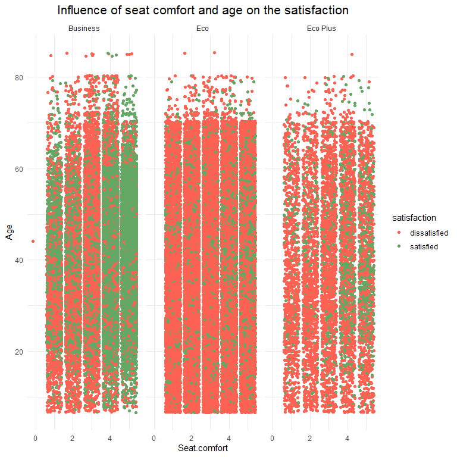

```r
ggplot(final_dataset) +
  aes(x = Seat.comfort, y = Age, colour = satisfaction) +
  geom_jitter(size = 1.5) +
  scale_color_manual(
    values = c(dissatisfied = "#FF6252",
               satisfied = "#65a765")) +
  theme_minimal() +
  facet_wrap(vars(Class)) +
  labs(title = "Influence of seat comfort and age on the satisfaction") +
  theme(plot.title = element_text(size = 16L, hjust = 0.5))
```

Several conclusions can be made from this graph: 1. The most dissatisfied passengers belong to Eco class, no matter the age. 2. The most uncomfortable seats are located in the Eco class. 3. As observed, it would be a good recommendation for airlines to upgrade their seats, as passengers tend to prefer a comfortable seat rather than the class. 4. The satisfaction does not depend on the age, moreover, we cannot be sure about this, so let’s try to figure this out in next questions.

```
Q3: Is the the age of the passenger related to the type of customer?
```

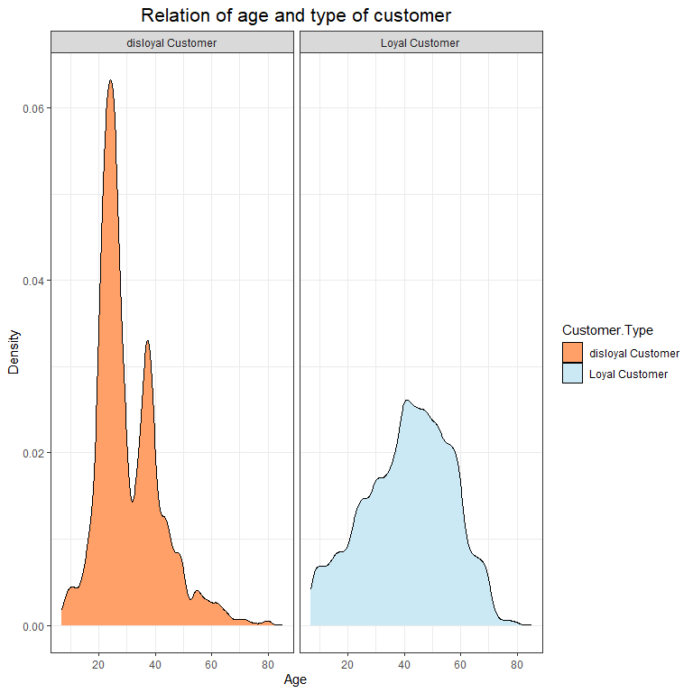

```r
ggplot(final_dataset) +
  aes(x = Age, fill = Customer.Type) +
  geom_density(adjust = 1L) +
  scale_fill_manual(values = c(`disloyal Customer` = "#FFA068",`Loyal Customer` = "#CAE9F5")) +
  labs(y = "Density") +
  theme_bw() +
  facet_wrap(vars(Customer.Type)) +
  labs(title = "Relation of age and type of customer") +
  theme(plot.title = element_text(size = 16L, hjust = 0.5))
```

From very little age to almost 35, and from age 35 to 40, the number of disloyal passengers is very high compared to loyal passengers. On the contrary, in age range 40 to 60, the number of loyal customers are higher compared to the rest.

```
Q4: Is the type of travel related, in a way or another, to the class of the passengers?
```

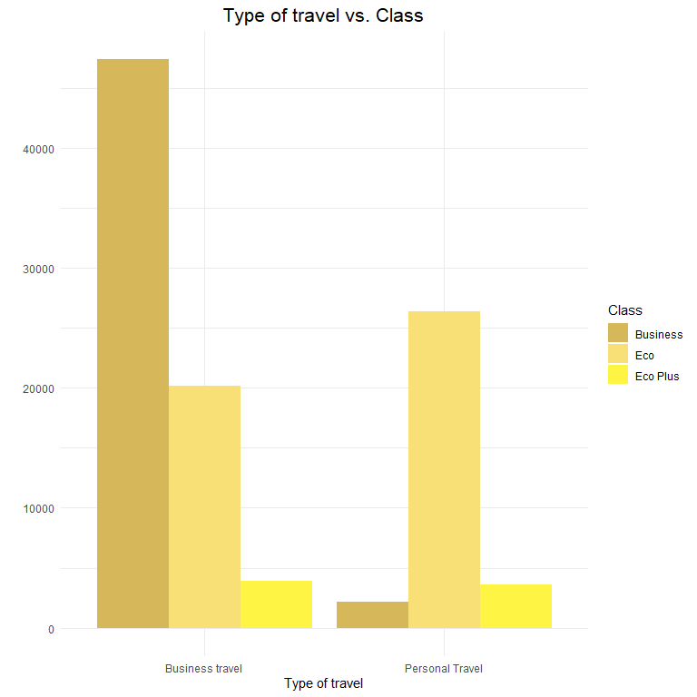

```r
ggplot(final_dataset) +
  aes(x = Type.of.Travel, fill = Class) +
  geom_bar(position = "dodge") +
  scale_fill_manual(values = c(Business = "#D6B85A", Eco = "#F9E076", `Eco Plus` = "#FDF443")) +
  labs(x = "Type of travel",y = '') +
  theme_minimal() +
  labs(title = "Type of travel vs. Class") +
  theme(plot.title = element_text(size = 16L, hjust = 0.5))
```

After an in-depth analysis of the graph exposed above, it is clear that those traveling because of business reasons tend to travel in business class, even though the number of those traveling in eco and eco plus are almost the same, no matter the type of travel.

```
Q5: Are the variables Departure.Delay.in.Minutes and Arrival.Delay.in.Minutes
related to the satisfaction?
```

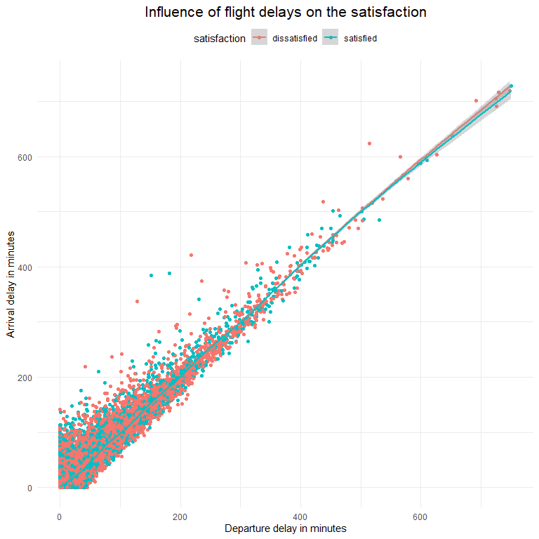

```r
final_dataset %>%
 filter(Departure.Delay.in.Minutes >= 0 & Departure.Delay.in.Minutes <= 750) %>%
 filter(Arrival.Delay.in.Minutes >= 0 & Arrival.Delay.in.Minutes <= 750) %>%
 ggplot() +
 aes(x = Departure.Delay.in.Minutes, y = Arrival.Delay.in.Minutes, colour = satisfaction) +
 geom_point(shape = "circle", size = 1.5) +
 scale_color_hue(direction = 1) +
 labs(x = "Departure delay in minutes", y = "Arrival delay in minutes") +
 theme_minimal() +
 theme(legend.position = "top") +
  geom_smooth() +
  labs(title = "Influence of flight delays on the satisfaction") +
  theme(plot.title = element_text(size = 16L, hjust = 0.5))
```

Indeed, there is a positive linear relationship between the variables. Concerning these variables, it is clear that the lower the delay, the more the satisfied number of passengers. Nonetheless, even with no delay there are still some passengers who are dissatisfied. This may be explained with other variables.

```
Q6:Is the satisfaction influenced by the variables Cleanliness, Ease.of.Online.booking,
Food.and.drink, and Seat.comfort?
```

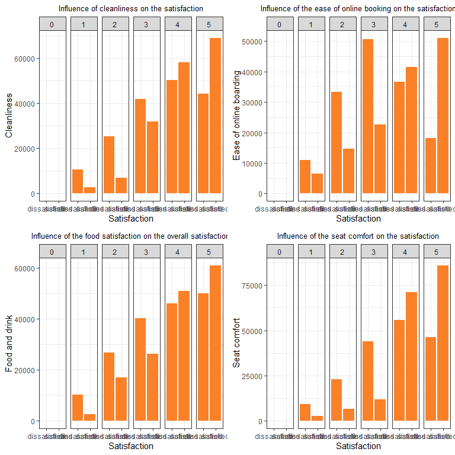

```r
plot1 <- ggplot(final_dataset) +
 aes(x = satisfaction, y = Cleanliness) +
 geom_col(fill = "#FA8128") +
 labs(x = "Satisfaction",
 y = "Cleanliness") +
 theme_bw() +
 facet_wrap(vars(Cleanliness), ncol = 6L) +
  labs(title = "Influence of cleanliness on the satisfaction") +
  theme(plot.title = element_text(size = 10L, hjust = 0.5))

plot2 <- ggplot(final_dataset) +
  aes(x = satisfaction, y = Ease.of.Online.booking) +
  geom_col(fill = "#FA8128") +
  labs(x = "Satisfaction",
       y = "Ease of online boarding") +
  theme_bw() +
  facet_wrap(vars(Ease.of.Online.booking), ncol = 6L) +
  labs(title = "Influence of the ease of online booking on the satisfaction") +
  theme(plot.title = element_text(size = 10L, hjust = 0.5))

plot3 <- ggplot(final_dataset) +
  aes(x = satisfaction, y = Food.and.drink) +
  geom_col(fill = "#FA8128") +
  labs(x = "Satisfaction",
       y = "Food and drink") +
  theme_bw() +
  facet_wrap(vars(Food.and.drink), ncol = 6L) +
  labs(title = "Influence of the food satisfaction on the overall satisfaction") +
  theme(plot.title = element_text(size = 10L, hjust = 0.5))

plot4 <- ggplot(final_dataset) +
  aes(x = satisfaction, y = Seat.comfort) +
  geom_col(fill = "#FA8128") +
  labs(x = "Satisfaction",
       y = "Seat comfort") +
  theme_bw() +
  facet_wrap(vars(Seat.comfort), ncol = 6L) +
  labs(title = "Influence of the seat comfort on the satisfaction") +
  theme(plot.title = element_text(size = 10L, hjust = 0.5))

plot_grid(plot1, plot2, plot3, plot4)
```

For all these features, the maximum number of satisfied passengers belong to categories 4 and 5. Below these, passengers are dissatisfied.

# 5 Classification.

As explained in the introduction of the project, supervised techniques adapt the model to reproduce outputs known from a training set. In the beginning, the system receives input data as well as output data. Its task is to create appropriate rules that map the input to the output. The training process should continue until the level of performance is high enough. After training, the system should be able to assign an output objects which it has not seen during the training phase. In most cases, this process is really fast and accurate.

One must know that there are two types of Supervised Learning techniques: Regression and Classification. Regarding the former, classification is a technique for reproducing class assignments. It can predict the response value and splits the data into classes. This can be the case of the recognition of a vehicle type in a photograph, or if whether or not an email is spam; regarding the latter, regression is a technique that aims to reproduce the output value. It can be used, for example, to predict the price of some product. Basically, regression fits the data.

Before starting, a prime point must be explained: as classification is used to predict a categorical variable from various inputs, “y” is categorical; whilst in regression “y” is numerical.

## 5.1 Statistical classification.

Statistical classification is a statistical procedure in which individual items are placed into groups based on quantitative information on one or more characteristics inherent in the items and based on a training set of previously labeled items.

There are some methods along the lines of: logistic regression (appropriate regression analysis to conduct when the dependent variable is binary) and Bayes classifiers (probabilistic model that makes the most probable prediction for a new example.)

Before starting, let’s split between training and test sets:

```r
# Split between training and testing sets. Due to the massiveness of the dataset,
# both underfitting and overfitting are desired to be prevented. Because of this,
# the data set is split in a 65-35 ratio.
spl = createDataPartition(final_dataset$satisfaction, p = 0.65, list = FALSE)  # 65% for training
PassengersTrain = final_dataset[spl,]
PassengersTest = final_dataset[-spl,]
```

### 5.1.1 Penalized logistic regression.

It is of high vitality to understand that there are two kinds of logistic regression. There is the “simple” logistic regression explained above; and the penalized logistic regression. The latter imposes a penalty to the logistic model for having too many variables. This results in shrinking the coefficients of the less contributive variables toward zero. This is also known as regularization

When the dimension is high, it is better to use a penalized version. The most known is glmnet or elasticnet.

```r
set.seed(123)
# To begin with, the function 'trainControl()' is used. The function trainControl
# generates parameters that further control how models are created, with important
# values like :
#     1. 'method': the resampling method. In this case, 'cv' was applied, which stands
#         for cross-validation (a statistical method of evaluating and comparing learning
#         algorithms by dividing data into two segments: one used to learn or train a model
#         and the other used to validate the model).
#     2. 'number': either the number of folds or the number of resampling iterations.
#         In this case, a 5-fold cross-validation is considered a good choice,
#         since it is considered to obtain pretty accurate results.

ctrl <- trainControl(method = "cv", number = 5,
                     classProbs = TRUE,
                     verboseIter=T)

# Then, the function 'train' is applied. This function sets up a grid of tuning
# parameters for a number of classification and regression routines, fits each
# model and calculates a resampling based performance measure. It contains
# important fields like:
#     1. 'satisfaction~.': it indicates which is the dependent variable.
#     2. 'method': a string specifying which classification or regression model
#         to use. 'glmnet' is the best for penalized logistic regression. It fits
#         generalized linear and similar models via penalized maximum likelihood.
#     3. 'tuneGrid': by default, caret will estimate a tuning grid for each method.
#         However, sometimes the defaults are not the most sensible given the nature
#         of the data. The tuneGrid argument allows the user to specify a custom
#         grid of tuning parameters as opposed to simply using what exists implicitly.
#     4. 'metric': a string that specifies what summary metric will be used to
#         select the optimal model. By default, possible values "Accuracy" and "Kappa"
#         for classification.

lrFit <- train(satisfaction ~ .,
               method = "glmnet",
               tuneGrid = expand.grid(alpha = seq(0, 1, 0.1), lambda = seq(0, .1, 0.02)),
               metric = "Kappa",
               data = PassengersTrain,
               preProcess = c("center", "scale"),
               trControl = ctrl)
print(lrFit)
```

```
## glmnet
##
## 67338 samples
##    22 predictor
##     2 classes: 'dissatisfied', 'satisfied'
##
## Pre-processing: centered (23), scaled (23)
## Resampling: Cross-Validated (5 fold)
## Summary of sample sizes: 53870, 53870, 53870, 53872, 53870
## Resampling results across tuning parameters:
##
##   alpha  lambda  Accuracy   Kappa
##   0.0    0.00    0.8733405  0.7406372
##   0.0    0.02    0.8733405  0.7406372
##   0.0    0.04    0.8716029  0.7369180
##   0.0    0.06    0.8695387  0.7325161
##   0.0    0.08    0.8684843  0.7301539
##   0.0    0.10    0.8675042  0.7279684
##   0.1    0.00    0.8757908  0.7459034
##   0.1    0.02    0.8740830  0.7421995
##   0.1    0.04    0.8721969  0.7381102
##   0.1    0.06    0.8702812  0.7339676
##   0.1    0.08    0.8692268  0.7316040
##   0.1    0.10    0.8681427  0.7291839
##   0.2    0.00    0.8757611  0.7458427
##   0.2    0.02    0.8742166  0.7424804
##   0.2    0.04    0.8724494  0.7386119
##   0.2    0.06    0.8703851  0.7341649
##   0.2    0.08    0.8690040  0.7310818
##   0.2    0.10    0.8672814  0.7272933
##   0.3    0.00    0.8757611  0.7458427
##   0.3    0.02    0.8739196  0.7418596
##   0.3    0.04    0.8723306  0.7383617
##   0.3    0.06    0.8696426  0.7325938
##   0.3    0.08    0.8674447  0.7278267
##   0.3    0.10    0.8657666  0.7240859
##   0.4    0.00    0.8757611  0.7458427
##   0.4    0.02    0.8737117  0.7414425
##   0.4    0.04    0.8717514  0.7371465
##   0.4    0.06    0.8685882  0.7303800
```

[output cut: 26 more lines]

```
##   0.9    0.00    0.8757611  0.7458448
##   0.9    0.02    0.8714247  0.7367391
##   0.9    0.04    0.8663755  0.7260684
##   0.9    0.06    0.8622174  0.7172031
##   0.9    0.08    0.8561139  0.7045861
##   0.9    0.10    0.8545695  0.7009115
##   1.0    0.00    0.8757462  0.7458133
##   1.0    0.02    0.8707564  0.7353483
##   1.0    0.04    0.8655142  0.7243437
##   1.0    0.06    0.8593810  0.7113650
##   1.0    0.08    0.8556387  0.7035695
##   1.0    0.10    0.8525053  0.6961594
##
## Kappa was used to select the optimal model using the largest value.
## The final values used for the model were alpha = 0.6 and lambda = 0.
```

```r
# Once the model is fit, it is time to check if it is a valid one or not.
# This will be tested on the testing dataset using the function 'predict'.
lrPred = predict(lrFit, PassengersTest)
```

Finally, it is time to check the effectiveness of our model using the confusion matrix. Being one of the pillars of data science, the confusion matrix is a performance measurement for machine learning classification. It is a table with 4 different combinations of predicted and actual values:

```
1. True Positive: You predicted positive and it’s true.
2. True Negative: You predicted negative and it’s true.
3. False Positive (Type 1 Error): You predicted positive and it’s false.
4. False Negative (Type 2 Error): You predicted negative and it’s false.
```

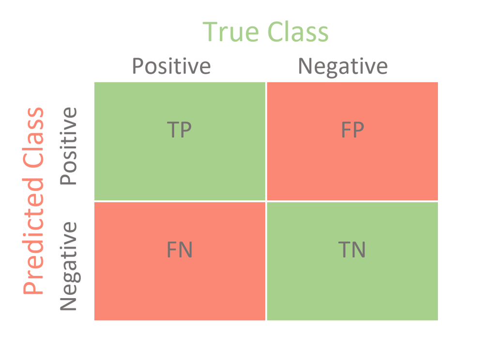

```r
confusionMatrix(lrPred, PassengersTest$satisfaction)
```

```
## Confusion Matrix and Statistics
##
##               Reference
## Prediction     dissatisfied satisfied
##   dissatisfied        18601      2643
##   satisfied            1942     13070
##
##                Accuracy : 0.8735
##                  95% CI : (0.8701, 0.8769)
##     No Information Rate : 0.5666
##     P-Value [Acc > NIR] : < 2.2e-16
##
##                   Kappa : 0.7411
##
##  Mcnemar's Test P-Value : < 2.2e-16
##
##             Sensitivity : 0.9055
##             Specificity : 0.8318
##          Pos Pred Value : 0.8756
##          Neg Pred Value : 0.8706
##              Prevalence : 0.5666
##          Detection Rate : 0.5130
##    Detection Prevalence : 0.5859
##       Balanced Accuracy : 0.8686
##
##        'Positive' Class : dissatisfied
##
```

Secondly, there is Kappa. The kappa statistic compares the observed accuracy to an expected accuracy or the accuracy expected from random chance. One of the flaws of pure accuracy is that if a class is imbalanced then making predictions at random could give a high accuracy score. Kappa accounts for this by comparing the model accuracy to the expected accuracy based on the number of instances in each class. Essentially it tells us how the model is performing compared to a model that classifies observations at random according to the frequency of each class. It returns a value at or below 1, negative values are possible.

One drawback of this statistic is that there is no agreed standard to interpret its values. Although, a general interpretation of the metric was given by Landis and Koch in 1977:

```
1. <0: Poor agreement,
2. 0.0-0.20: Slight agreement.
3. 0.21-0.40: Fair agreement.
4. 0.41-0.60: Moderate agreement.
5. 0.61-0.80: Substantial agreement.
6. 0.81-1: Almost perfect agreement.
```

In this case, we obtained 0.7411, considered a good result, although not perfect. Finally, there are two more measures worth mentioning: sensitivity and specificity. The former is the metric that evaluates a model’s ability to predict true positives of each available category; the latter is the metric that evaluates a model’s ability to predict true negatives of each available category. Both range from 0 to 1. For both cases, very good results were obtained: 0.9055 and 0.8318, respectively.

Even though this represents a good model, let’s try to get a better one.